# Dplyr

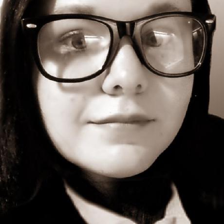

Hi, My name is Kimberly Staudt. I am a data science student at Mercyhurst University.The purpose of this website is to give a brief tutorial on R, using the dplyer function and lahman baseball database.

## Filtering Columns and Rows

### Introduction

When utilizing dplyr, you can filter columns and rows by using select and filter. The lahman baseball database provides all of the data we will need for the following examples. First, load the database along with dplyr by selecting the “Install Packages” button under “Tools”. Use the library function, as seen below, to load packages.

```r
library(Lahman)
library(dplyr)
```

**Example #1**

First, let us specify a year, such as 1927, for the NY Yankees and exam all home runs within that year.

```r
Batting%>%
  select(playerID,yearID,teamID,HR)%>%
  filter(teamID=="NYA" & yearID==1927)
```

```
##     playerID yearID teamID HR
## 1  beallwa01   1927    NYA  0
## 2  bengobe01   1927    NYA  0
## 3  collipa01   1927    NYA  7
## 4  combsea01   1927    NYA  6
## 5  duganjo01   1927    NYA  2
## 6  durstce01   1927    NYA  0
## 7  gazelmi01   1927    NYA  0
## 8  gehrilo01   1927    NYA 47
## 9  giardjo01   1927    NYA  0
## 10 grabojo01   1927    NYA  0
## 11  hoytwa01   1927    NYA  0
## 12 koenima01   1927    NYA  3
## 13 lazzeto01   1927    NYA 18
## 14 meusebo01   1927    NYA  8
## 15 moorewi01   1927    NYA  1
## 16 morehra01   1927    NYA  1
## 17 paschbe01   1927    NYA  2
## 18 pennohe01   1927    NYA  0
## 19 pipgrge01   1927    NYA  1
## 20 ruethdu01   1927    NYA  1
## 21  ruthba01   1927    NYA 60
## 22 shawkbo01   1927    NYA  0
## 23 shockur01   1927    NYA  0
## 24 thomamy01   1927    NYA  0
## 25  weraju01   1927    NYA  1
```

**Example #2**

Below, you will find Yankees who have hit 40 or more homeruns.

```r
Batting%>%
  select(playerID,yearID,teamID,HR)%>%
  filter(teamID=="NYA" & HR>=40)
```

```
##     playerID yearID teamID HR
## 1   ruthba01   1920    NYA 54
## 2   ruthba01   1921    NYA 59
## 3   ruthba01   1923    NYA 41
## 4   ruthba01   1924    NYA 46
## 5   ruthba01   1926    NYA 47
## 6  gehrilo01   1927    NYA 47
## 7   ruthba01   1927    NYA 60
## 8   ruthba01   1928    NYA 54
## 9   ruthba01   1929    NYA 46
## 10 gehrilo01   1930    NYA 41
## 11  ruthba01   1930    NYA 49
## 12 gehrilo01   1931    NYA 46
## 13  ruthba01   1931    NYA 46
## 14  ruthba01   1932    NYA 41
```

[output cut: 16 more lines]

**Example #3**

```r
 Batting%>%
    select(playerID,yearID,teamID,HR,SO)%>%
    filter(HR>40 & SO<60)
```

```
##     playerID yearID teamID HR SO
## 1  hornsro01   1922    SLN 42 50
## 2  willicy01   1923    PHI 41 57
## 3    ottme01   1929    NY1 42 38
## 4  gehrilo01   1931    NYA 46 56
## 5   ruthba01   1931    NYA 46 51
## 6  gehrilo01   1934    NYA 49 31
## 7  gehrilo01   1936    NYA 49 46
## 8  troskha01   1936    CLE 42 58
## 9  dimagjo01   1937    NYA 46 37
## 10  mizejo01   1940    SLN 43 49
## 11  mizejo01   1947    NY1 51 42
## 12 willite01   1949    BOS 43 48
## 13 kinerra01   1951    PIT 42 57
## 14 camparo01   1953    BRO 41 58
## 15 rosenal01   1953    CLE 43 48
## 16 kluszte01   1954    CIN 49 35
## 17  mayswi01   1954    NY1 41 57
## 18 kluszte01   1955    CIN 47 40
## 19 aaronha01   1957    ML1 44 58
## 20 sievero01   1957    WS1 42 55
## 21 aaronha01   1969    ATL 44 47
## 22 aaronha01   1971    ATL 47 58
## 23 thomafr04   1993    CHA 41 54
## 24 bondsba01   2002    SFN 46 47
## 25 bondsba01   2003    SFN 45 58
## 26 bondsba01   2004    SFN 45 41
## 27 pujolal01   2004    SLN 46 52
## 28 pujolal01   2006    SLN 49 50
```

**Example #4**

The table below shows all Philly players who hit more than 30 homeruns in the 1970’s.

```r
 Batting%>%
    select(playerID,yearID,teamID,HR)%>%
    filter(HR>30 & yearID>=1970 & yearID<=1979 & teamID=="PHI")
```

```
##    playerID yearID teamID HR
## 1 johnsde01   1971    PHI 34
## 2 schmimi01   1974    PHI 36
## 3 luzingr01   1975    PHI 34
## 4 schmimi01   1975    PHI 38
## 5 schmimi01   1976    PHI 38
## 6 luzingr01   1977    PHI 39
## 7 schmimi01   1977    PHI 38
## 8 luzingr01   1978    PHI 35
## 9 schmimi01   1979    PHI 45
```

## Arrange

With arrange we can order our results by specifying the order in which they appear.

**Example #5**

In this example, we can find every instance where a player has more than 50 homeruns, however the players with the most homeruns are at the top of the list.

```r
 Batting%>%
    select(playerID,yearID,teamID,HR)%>%
    filter(HR>50)%>%
    arrange(desc(HR))
```

```
##     playerID yearID teamID HR
## 1  bondsba01   2001    SFN 73
## 2  mcgwima01   1998    SLN 70
## 3   sosasa01   1998    CHN 66
## 4  mcgwima01   1999    SLN 65
## 5   sosasa01   2001    CHN 64
## 6   sosasa01   1999    CHN 63
## 7  marisro01   1961    NYA 61
## 8   ruthba01   1927    NYA 60
## 9   ruthba01   1921    NYA 59
## 10  foxxji01   1932    PHA 58
## 11 greenha01   1938    DET 58
## 12 howarry01   2006    PHI 58
## 13 gonzalu01   2001    ARI 57
## 14 rodrial01   2002    TEX 57
```

[output cut: 22 more lines]

**Example #6**

Next, we will list all instances of players who struck out less than 10 times, but have to have at least 400 bats (AB).

```r
 Batting%>%
    select(playerID,yearID,teamID,SO,AB)%>%
    filter(AB>=400 & SO<10 )%>%
    arrange(SO)
```

```
##     playerID yearID teamID SO  AB
## 1  doyleja01   1894    NY1  3 422
## 2  seweljo01   1932    NYA  3 503
## 3  seweljo01   1925    CLE  4 608
## 4  seweljo01   1929    CLE  4 578
## 5  seweljo01   1933    NYA  4 524
## 6   wardjo01   1893    NY1  5 588
## 7  holloch01   1922    CHN  5 592
## 8  mcinnst01   1922    CLE  5 537
## 9  wanerll01   1936    PIT  5 414
## 10 wrighge01   1875    BS1  6 408
## 11 broutda01   1889    BSN  6 485
## 12 keelewi01   1894    BLN  6 590
## 13  wardjo01   1894    NY1  6 540
## 14 quinnjo02   1895    SLN  6 543
```

[output cut: 51 more lines]

## Aggregation

Aggregation is useful to sum or total the averages, as well as any maximums and minimums.

**Example #7**

Here, we add the total number of career homeruns for the player Babe Ruth

```r
 Batting%>%
  filter(playerID=='ruthba01')%>%
  group_by(playerID)%>%
  summarize(career_HR=sum(HR))
```

```
## # A tibble: 1 x 2
##   playerID career_HR
##      <chr>     <int>
## 1 ruthba01       714
```

**Example #8**

The example below uses aggregation to find the career totals for all players with 600 homeruns or more, with the highest totals arranged at the top.

```r
 Batting%>%
  group_by(playerID)%>%
  summarize(career_HR=sum(HR))%>%
  filter(career_HR>=600)%>%
  arrange(desc(career_HR))
```

```
## # A tibble: 8 x 2
##    playerID career_HR
##       <chr>     <int>
## 1 bondsba01       762
## 2 aaronha01       755
## 3  ruthba01       714
## 4 rodrial01       696
## 5  mayswi01       660
## 6 griffke02       630
## 7 thomeji01       612
## 8  sosasa01       609
```

**Example #9**

We can also look at the average homeruns of all players, but limit it to those with more than 30 homeruns.

```r
 Batting%>%
  group_by(playerID)%>%
  summarize(HRAvg=mean(HR))%>%
  filter(HRAvg>30)%>%
  arrange(desc(HRAvg))
```

```
## # A tibble: 13 x 2
##     playerID    HRAvg
##        <chr>    <dbl>
##  1 pujolal01 36.93750
##  2 bondsba01 34.63636
##  3 mcgwima01 34.29412
##  4 kinerra01 33.54545
##  5 aaronha01 32.82609
##  6 bryankr01 32.50000
##  7  ruthba01 32.45455
##  8  sosasa01 32.05263
##  9 cabremi01 31.85714
## 10 belleal01 31.75000
## 11 rodrial01 31.63636
## 12 schmimi01 30.44444
## 13 abreujo02 30.33333
```

**Example #10** For our last example, let’s look at players who have hit more than 50 homeruns since the 1970’s.

```r
 Batting%>%
  filter(yearID>=1970)%>%
  group_by(playerID,yearID)%>%
  summarize(maxHR=mean(HR))%>%
  filter(maxHR>50)
```

```
## # A tibble: 21 x 3
## # Groups:   playerID [14]
##     playerID yearID maxHR
##        <chr>  <int> <dbl>
##  1 bautijo02   2010    54
##  2 bondsba01   2001    73
##  3 davisch02   2013    53
##  4 fieldce01   1990    51
##  5 fostege01   1977    52
##  6 gonzalu01   2001    57
##  7 griffke02   1997    56
##  8 griffke02   1998    56
##  9 howarry01   2006    58
## 10 jonesan01   2005    51
## # ... with 11 more rows
```